# Exploring data with Graphical Displays

Anthony Wen

2024-01-24

Please complete the following:

- Address each of the following questions below.
- Compile the document into a multipage PDF file
- Submit to Gradescope and paginate individual questions correctly

### Question 1 - Exploring Data with Histograms [4 points]

Using the county dataset, choose one of the numeric variables to construct a histogram for. (Due to extreme values, I recommend avoiding population variables.)

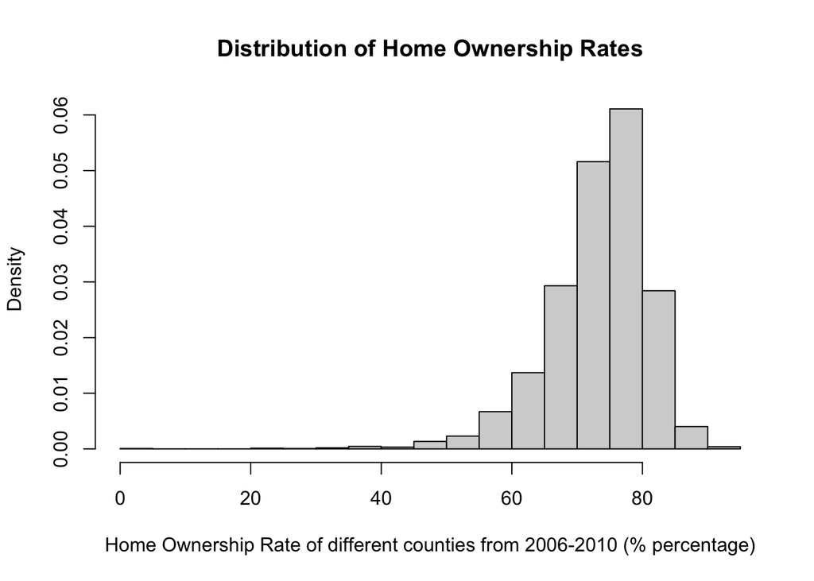

```r
# Include code here to construct a histogram from the county dataset
#  Be sure to change the labels of the axes to be a proper graphical display!
# hist(NA, xlab='xlabel', ylab='ylabel', main='title')

hist(county$homeownership,freq = FALSE,breaks=20,
     xlab = "Home Ownership Rate of different counties from 2006-2010 (% percentage)",
     main = "Distribution of Home Ownership Rates")
```

#### For your histogram, address the following below:

- What is the shape of the distribution of this variable?
- Can you explain any trends you see in the shape in the context of the data?

The shape of this variable is most similar to a negative skew. For the 0-50% of home ownership range, the density is really different from the majority of the dataset from 60% and above. This means that the percentage of home ownership in different counties are mostly between 60% and 80% with the peak distribution between 70% to 80% (the mean is around 73%). So, there is a larger amount of counties that have high home ownership rate as opposed to low home ownership rates.

### Question 2 - Exploring Data with Boxplots (Comparing States) [4 points]

First, copy your code used to make clustered samples to the code chunk provided below. Do not edit the `set.seed(311)` command, to ensure your results are consistent each time knitr is compiled.

```r
set.seed(311)
# Include your code from HW1 to create the my.Clustered dataset. Keep the added last line at the end.

clusters = sample(unique(county$state),5)
#clusters

clusters2 <- county[0,]
for (cluster in clusters){
  temp<-county[county$state==cluster,]
  clusters2 <- rbind(clusters2,temp)
}
my.Clustered <- clusters2

#This should only give 5 total states
unique(my.Clustered$state)
```

```
## [1] Wyoming      South Dakota Maryland     Nebraska     Connecticut
## 51 Levels: Alabama Alaska Arizona Arkansas California Colorado ... Wyoming
```

```r
# Do not touch the code below.
my.Clustered$state<-droplevels(my.Clustered$state)
```

Using your cluster sample, choose one of the numeric variables to construct a set of compariative boxplot comparing results between the five different states in your sample. (Due to extreme values, I recommend avoiding population variables.)

[figure not shown]

```r
# Include code here to construct a compariative boxplot from the states in your
#  my.Clustered dataset
#  Be sure to change the labels of the axes to be a proper graphical display!
# boxplot(NA~my.Clustered$state, xlab='xlabel', ylab='ylabel', main='title')

boxplot(my.Clustered$multi_unit~my.Clustered$state,xlab = "State",
        ylab = "Percentage of Population in Poverty (%)",
        main= "Comparing the Percentage of Poverty by State")
```

### Question 3 - Exploring Data with Boxplots (Comparing Education Level) [4 points]

Using the full county dataset, choose one of the numeric variables to construct a set of compariative boxplot comparing results between the four different education levels. (Due to extreme values, I recommend avoiding population variables, but an enterprising student may attempt a log-transformation of that variable here.)

[figure not shown]

```r
# Include code here to construct a compariative boxplot from the education
# levels in the county dataset
#  Be sure to change the labels of the axes to be a proper graphical display!
# boxplot(NA~county$median_edu, xlab='xlabel', ylab='ylabel', main='title')

boxplot(county$median_hh_income~county$median_edu,xlab = "Median Household Income ($)",ylab = "Education Level",main="Comparing Median Household Income and Median Education Levels")
```

#### For your boxplots, address the following below:

- What trends do you notice when comparing the variable of interest for different education levels?
- Can you explain the trends you are observing based on your knowledge of how levels of education might relate to your variable of interest?

From the plot, we can see a postive correlation between the median education level and median household income in the county. The higher the income, the higher the education level which suggest a right-skewed graph.The variability also seems to increase along this trend, the higher the education level (and income) the wider the IQR and the more outliers there might be (other than in the Bachelors catagory). This might be because the more money you have, the more resources you might be able to obtain which of course also includes education. Also, when people have a higher education level, they gain more experience and knowledge which suggests more job opportunities avalible to them. There will also have high salary levels (income).

### Question 4 - Exploring Data with Scatterplots [4 points]

Using the full county dataset, choose two of the numeric variables to construct a scaterplot to examine how the variables relate to each other. (Due to extreme values, I recommend avoiding population variables, but an enterprising student may attempt a log-transformation of that variable here. Regardless, I would not use population twice as it is not very interesting!)

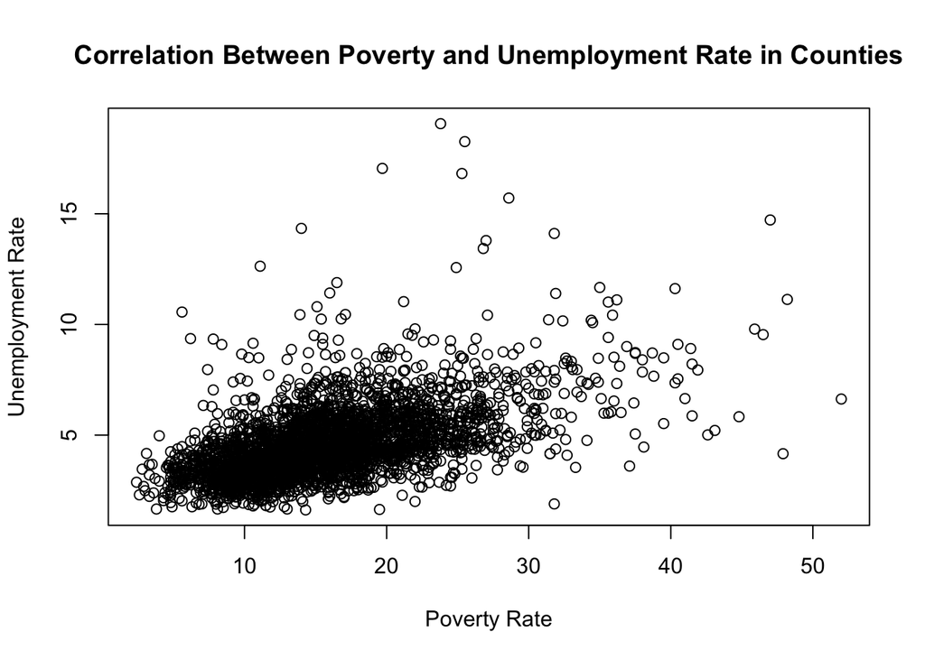

```r
# Include code here to construct a scatterplot from the county dataset
#  Be sure to change the labels of the axes to be a proper graphical display!

# plot(county$Y~county$X, xlab='xlabel', ylab='ylabel', main='title')
# or
# plot(county$X, county$Y, xlab='xlabel', ylab='ylabel', main='title')

plot(county$unemployment_rate~county$poverty,xlab= 'Poverty Rate',ylab = 'Unemployment Rate',main='Correlation Between Poverty and Unemployment Rate in Counties')
```